# instabot-2

```python
#importing all the necessary packages
from selenium import webdriver                                    #importing webdriver
from selenium.webdriver.support.ui import WebDriverWait           #To use implcit and explicit wait
from selenium.webdriver.support import expected_conditions as EC  #use in explicitly wait
from selenium.webdriver.common.by import By                       #to select the attribute by Class,link_text
from selenium.webdriver.support.ui import Select
import time
from bs4 import BeautifulSoup                                              #work with attribute
from selenium.common.exceptions import TimeoutException
from selenium.common.exceptions import StaleElementReferenceException  #to handle StaleElementReferenceException
from selenium.webdriver.common.keys import Keys #For navigating the pop up window
from selenium.common.exceptions import NoSuchElementException #to handle NoSuchElementException
from collections import Counter #for extracting the top n number of counts in dictionary
import matplotlib.pyplot as plt                                            #for plotting the graph
import pandas as pd
import csv
```

```python
# Log in to the instagram
driver=webdriver.Chrome(executable_path='C:/Users/singh/chromedriver') #path of
driver.get('https://www.instagram.com/') #navigating to the instagram log in page
wait = WebDriverWait(driver, 10)
name= wait.until(EC.presence_of_element_located((By.NAME,'username'))) #locating the box to insert name of the user
name.send_keys('ra.njeet9098') # passing username
pas=driver.find_element_by_name('password') # locating the box to insert the password of the user
pas.send_keys('Ranjeet1996@') #passinf password
login=driver.find_element_by_class_name('L3NKy') #serch for login button
login.click() #clicking on the login button
```

1. Now your friend has followed a lot of different food bloggers, he needs to analyse the habits of these bloggers.

   A. From the list of instagram handles you obtained when you searched ‘food’ in previous project. Open the first 10 handles and find the top 5 which have the highest number of followers

```python
search=driver.find_element_by_xpath('//input[contains(@class,"XTCLo")]') #loacting the search box
search.send_keys("food")                                                #sending values for searching
time.sleep(3)
val=driver.find_elements_by_xpath('//div[@class = "fuqBx"]/a["href"]')  #fetching food list Handles
food=[] #creating an empty list for appending the list of food handlers
for i in val[0:10]: #selecting first 10
    if 'explore' in i.get_attribute('href'):        #if explore present in link then it is hastags
        continue
    else:
        s = i.get_attribute('href').split('/')      #https://www.instagram.com/foodtalkindia
        #print(s[3])                                     # after split s= ['https:','','www.instagram.com','stockholmfood']
        if 'foodie_since97' not in s[3]:#as 'foodie_since97' private account we can't access the followers
            food.append(s[3])                          #appending s[3] in food_list
a=driver.find_element_by_xpath('//input[contains(@class,"XTCLo")]')  #seaeching  input box
a.clear() #clearing the input  box
b=driver.find_element_by_class_name('coreSpriteSearchClear').click() #selecting clear box by class name and clicking it
#new_food=food[:10]
followers=[] #creating an empty dictionary for storing the nuber of followers.
for i in food:#opening each and ever profile of first 10 followers and then navigating back to the home-page
    search=driver.find_element_by_xpath('//input[contains(@class,"XTCLo")]') #loacting the search box
    #a.clear()
    search.send_keys(i) #sending the values for serching in search bar
    b = wait.until(EC.presence_of_element_located((By.CLASS_NAME,'yCE8d')))     #selecting the follower-page
    b.click() #clicking it to open  the profile
    time.sleep(3)
    l=driver.find_element_by_xpath('//a[contains(@class, "-nal3")]/span').get_attribute('title') #ectracting the number of followers
    s=l.replace(',','')
    followers.append(int(s))

    driver.back() #navigating back to the home-page

res = {food[i]: int(followers[i]) for i in range(len(food))} #creating a dictionry with user name as keys and number of followers values
od=dict(Counter(res).most_common(5)) #extracting top 5 followers profiles
od
```

```
{'foodnetwork': 10983105,
 'yourfoodlab': 1546304,
 'foodrush.recipe': 617838,
 'foodie_incarnate': 244497,
 'delhifoodwalks': 133288}
```

B. Now Find the number of posts these handles have done in the previous 3 days.

```python
no_of_post={}
for handle in od:
    search = driver.find_element_by_xpath('//div[contains(@class,"LWmhU")]/input')   #input box
    search.send_keys(handle)                                                         #send hadles to search box
    b = wait.until(EC.presence_of_element_located((By.CLASS_NAME,'z556c')))          #first profile
    first_search = driver.find_element_by_class_name('z556c')
    first_search.click()
    a= wait.until(EC.presence_of_element_located((By.XPATH,'//input[contains(@class,"XTCLo")]')))  #clearing input box
    a.clear()
    count = 0
    i=0
    for i in range(12):
        driver.execute_script('window.scrollBy(0,document.body.scrollHeight);')                #scrolling 7 time to done side
        time.sleep(1)
    data=driver.find_elements_by_xpath('//div[contains(@class,"_9AhH0")]')                     #fetching the post
    for j in range(12):
        driver.execute_script('window.scrollBy(0,-document.body.scrollHeight);')               #scrolling upside to move top
        time.sleep(1)
    #driver.execute_script('window.scrollBy(0,500);')                                           #scrolling downside ot mave till post
    final=data
    for i in range(len(final)):
        post=driver.find_elements_by_xpath('//div[contains(@class,"_9AhH0")]')               #finding post
        driver.execute_script('window.scrollBy(0,80);')                                      #scrolling by 80 downside
        wait = WebDriverWait(driver, 15)                                                     #wait time
        post[i].click()                                                                      #click on each post
        test= wait.until(EC.presence_of_element_located((By.XPATH,'//time[contains(@class,"FH9sR")]'))) #test button
        val=test.text                            #fetch text
        time.sleep(2)
        if val[-1]=='d': #d for days,h for hours and m for mins
            new_val=int(val[0:-1])
            if new_val<4: #4 represents 4 day and so i have used this condition to extart info for only three notes
                count=count+1
            else:
                new=driver.find_elements_by_xpath('//button[contains(@class,"wpO6b")]/div')[-1] #extractint the close button
                new.click()#clicking the close button to close the post
                break
        else:
            if val[-1]=='h': #d for days,h for hours and m for mins
                count=count+1
            elif val[-1]=='m': #d for days,h for hours and m for mins
                count=count+1
            else:
                new=driver.find_elements_by_xpath('//button[contains(@class,"wpO6b")]/div')[-1] #extractint the close button
                new.click() #clicking the close button to close the post
                break

        close_btn = driver.find_elements_by_xpath('//button[contains(@class,"wpO6b")]/div')[-1]      #post close button
        close_btn.click()                                           #click on close button
        time.sleep(2)
    no_of_post[handle]=count                                       #count adding in dictionary
handles=[] #empty list for handlers name
number_posts=[] #emtpy list to count number of posts
for i in no_of_post:
    handles.append(i)
    number_posts.append(no_of_post[i])
for i in range(len(handles)):
    print(handles[i],'',number_posts[i])#printing name with the number of post for the last 3 days
```

```
foodnetwork  30
yourfoodlab  4
foodrush.recipe  2
foodie_incarnate  5
delhifoodwalks  4
```

C. Depict this information using a suitable graph.

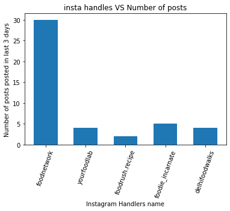

```python
plt.bar(handles,number_posts,width=0.6)
plt.xticks(rotation=70)
plt.title('insta handles VS Number of posts')
plt.xlabel('Instagram Handlers name')
plt.ylabel('Number of posts posted in last 3 days')

plt.show()
```

1. Your friend also needs a list of hashtags that he should use in his posts.

   A. Open the 5 handles you obtained in the last question, and scrape the content of the first 10 posts of each handle.

```python
top_5_post_content={}
for t in od:
    post_content={}
    data=driver.find_element_by_xpath('//input[contains(@class,"XTCLo")]') #input box
    data.send_keys(t)  #send hadlers name to search box
    driver.implicitly_wait(10)
    data=driver.find_element_by_xpath('//span[contains(@class,"Ap253")]') #first profile
    data.click() #clicking it to open the profile page
    driver.implicitly_wait(10)
    for i in range(1):
        driver.execute_script('window.scrollBy(0,document.body.scrollHeight);')                      #down scrolling
        time.sleep(1)
    data=driver.find_elements_by_xpath('//div[contains(@class,"_9AhH0")]')                           #fetching the data
    for j in range(1):
        driver.execute_script('window.scrollBy(0,-document.body.scrollHeight);')                     #up scrolling
        time.sleep(1)

    driver.execute_script('window.scrollBy(0,500);')
    driver.execute_script('window.scrollBy(0,500);')
    for p in range(10):
        data=driver.find_elements_by_xpath('//div[contains(@class,"_9AhH0")]')#fetch the post
        driver.execute_script('window.scrollBy(0,80);') # scroll by 80
        driver.implicitly_wait(10)
        data[p].click() #clicking on each post to extract the contents
        driver.implicitly_wait(10)
        con='post'+str(p+1)
        data=driver.find_element_by_xpath('//div[contains(@class,"C4VMK")]/span')#clicking on each post
        value=data.text#text data
        post_content[con]=value
        new=driver.find_elements_by_xpath('//button[contains(@class,"wpO6b")]/div')[-1] #extractint the close button
        new.click()#clicking the close botton
    top_5_post_content[t]=post_content
for i in top_5_post_content:
    print(i)
    print('####################')
    print(top_5_post_content[i])
    print('***************************************')
```

```
foodnetwork
####################
{'post1': 'Spicy Garlic Wings (with @guyfieri) 🔥\n\nScreaming red wings from @ob_noodlehouse are a garlic lover\'s dream!\n\nCatch #DDD with @guyfieri > Fridays at 9|8c and subscribe to @discoveryplus to stream the entire library and so much more: http://discoverypl.us/34WCE6K. #discoveryplus (Head …
yourfoodlab
####################
{'post1': 'Trending wrap hack #1 Aloo Tikki wrap! Will be uploading 5 more of these crazy wrap ideas. Stay tuned ✌️\n.\n.\n.\n#reeitfeelit #reelkarofeelkaro #reelsinstagram #foodstagram #tortilla #wraphack #tortillawrap #food #hack #hackvideo', 'post2': 'Cheesy Tava Paneer Hot Dog by Chef @sanjyotke…
foodrush.recipe
####################
{'post1': 'Cheese Pav bhaji is one of the best version of street food we all have ever tasted. We have just tried to serve it in a most convenient yet cheesy way with @gocheesein 😋This recipe is specially for all cheese lovers out there cause #HarTastyCheezMeinGoCheese !!! Ingredients:\n2 cup Refine…
foodie_incarnate
####################
{'post1': '130Rs Ganne Ka Juice🤭🤭\n.\n📍Foodhall, DLF Promenade , Vasant Kunj, Delhi\n\n#foodieincarnate #reelitfeelit #reelkarofeelkaro #reels #reelsinstagram #costlyfood #delhifoodie #delhi #gannekajuice #sugarcanejuice', 'post2': 'The TASTIEST Paneer Tikka Sandwich in Delhi❤👌🏻\n\n.\n📍@wow_sandwich…
delhifoodwalks
####################
{'post1': 'New video featuring the story of the Poders from Goa is now up on our YouTube channel.\n\nHead to the link in the bio to discover more about these traditional bakers and their humble artisanal fares which is the lifeline of the Goan populace.\n\nThis exploration centres around one of the …
```

B. Prepare a list of all words used in all the scraped posts and calculate the frequency of each word.

```python
total_words_freq={} #dictionary to store words as key and values a count
for i in top_5_post_content:
    val=top_5_post_content[i]
    for j in range(10):
        post_number='post'+str(j+1)
        new_val=val[post_number]
        final_val=new_val.split()  #spliting each and every post
        for k in final_val:
            if k[0]=='#':  #only fetching hastages
                ans=k[1:]
                if ans in total_words_freq:
                    total_words_freq[ans]+=1
                else:
                    total_words_freq[ans]=1
print(total_words_freq)
```

```
{'DDD': 2, 'discoveryplus': 4, 'DeliciousMissBrown': 2, 'WorstCooks': 1, 'TheKitchen': 1, 'discoveryplus\u2060': 2, 'KidsBakingChampionship': 1, 'GirlMeetsFarm': 1, 'discoveryplus!': 1, '1': 1, 'reeitfeelit': 1, 'reelkarofeelkaro': 2, 'reelsinstagram': 2, 'foodstagram': 5, 'tortilla': 1, 'wraphack':…
```

C. Create a csv file with two columns : the word and its frequency

```python
freq_of_words=[] #creating an empty list
for i in total_words_freq:
    freq_of_words.append([i,total_words_freq[i]])
df=pd.DataFrame(freq_of_words,columns=['words','Frequency'])
df.to_csv('freq_of_words.csv',index=False) #creating the csv file.
print(df)
```

```
                  words  Frequency
0                   DDD          2
1         discoveryplus          4
2    DeliciousMissBrown          2
3            WorstCooks          1
4            TheKitchen          1
..                  ...        ...
267            Festival          1
268              Punjab          1
269         makkikiroti          1
270        sarsonkasaag          1
271              rewari          1

[272 rows x 2 columns]
```

D. Now, find the hashtags that were most popular among these bloggers

```python
top_5_most_popular_hastags=dict(Counter(total_words_freq).most_common(5)) #extracting top 5 hastags which are most popular among these bloggers
top_5_most_popular_hastags
```

```
{'food': 17, 'streetfood': 16, 'foodie': 16, 'recipe': 14, 'foodporn': 11}
```

E. Plot a Pie Chart of the top 5 hashtags obtained and the number of times they were used by these bloggers in the scraped posts.

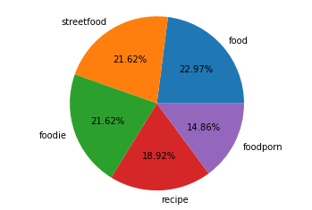

```python
hastags=[]
counts=[]
for i in top_5_most_popular_hastags:
    hastags.append(i)
    counts.append(top_5_most_popular_hastags[i])
plt.pie(counts,labels=hastags,autopct="%.2f%%")
plt.axis('equal')
plt.show()
```

1. You need to also calculate average followers : likes ratio for the obtained handles. Followers : Likes ratio is calculated as follows:

A. Find out the likes of the top 10 posts of the 5 handles obtained earlier.

```python
top_5_post_like={}                                                          #empty dictionary for top five post
for t in od:
    post_likes={}
    count=0
    data=driver.find_element_by_xpath('//input[contains(@class,"XTCLo")]')  #input box
    data.send_keys(t)                                                       #send handle
    driver.implicitly_wait(10)
    data=driver.find_element_by_xpath('//span[contains(@class,"Ap253")]')   #first search
    data.click()
    driver.implicitly_wait(10)
    for i in range(12):
        driver.execute_script('window.scrollBy(0,2000);')                  #scroll by 2000
        time.sleep(1)
    data=driver.find_elements_by_xpath('//div[contains(@class,"_9AhH0")]') #fetch the elements
    for j in range(12):
        driver.execute_script('window.scrollBy(0,-2000);')                 #scroll by 2000
        time.sleep(1)
    driver.execute_script('window.scrollBy(0,500);')                       #make in proper place f post
    driver.execute_script('window.scrollBy(0,500);')
    final=data
    driver.implicitly_wait(10)
    for p in range(len(final)):
        if count>9:
            break
        try:
            data=driver.find_elements_by_xpath('//div[contains(@class,"_9AhH0")]')  #fetch post
            driver.execute_script('window.scrollBy(0,80);')
            final=len(data)
            driver.implicitly_wait(10)

            data[p].click()
            driver.implicitly_wait(10)
            data=driver.find_element_by_xpath('//button[contains(@class,"sqdOP ")]//span')  #find likes on post
            val=data.text
            if val=='':
                new=driver.find_elements_by_xpath('//button[contains(@class,"wpO6b")]/div')[-1] #extractint the close button
                new.click()
                continue
            if val[0]=='V':
                new=driver.find_elements_by_xpath('//button[contains(@class,"wpO6b")]/div')[-1] #extracting the close button
                new.click()
                continue
            val=val.replace(',','')
            ans=val
            count=count+1
            number='post'+str(count)
            post_likes[number]=ans
            new=driver.find_elements_by_xpath('//button[contains(@class,"wpO6b")]/div')[-1] #extracting the close button
            new.click()

        except NoSuchElementException:
            new=driver.find_elements_by_xpath('//button[contains(@class,"wpO6b")]/div')[-1] #extracting the close button
            new.click()

    top_5_post_like[t]=post_likes
print(top_5_post_like)
```

```
{'foodnetwork': {'post1': 'Hide replies', 'post2': '15082', 'post3': 'Hide replies', 'post4': 'Hide replies', 'post5': '8225', 'post6': '13871', 'post7': 'Hide replies', 'post8': '14073', 'post9': '7633', 'post10': '17692'}, 'yourfoodlab': {'post1': '35973', 'post2': '33021', 'post3': '38902', 'post…
```

B. Calculate the average likes for a handle.

```python
average_handles={} #empty dic to store average value as key and handlers name as value
for i in top_5_post_like:
    c=0
    tsum=0
    d=top_5_post_like[i]#extracting each and every post likes
    #print(d)
    d = [d[w].replace('Hide replies', '0') for w in d]#replacing the hidden likes counts with 0
    for j in d:
        c=c+1
        tsum+=int(j)#converting the values from string to int and summing up them.
        average=tsum/c #calculating the average
    average_handles[i]=average
for key in average_handles.keys():
    print(key,end="    ")
    print("{0:.2f}".format(average_handles[key]))
```

```
foodnetwork    7657.60
yourfoodlab    29209.70
foodrush.recipe    18175.25
foodie_incarnate    4120.10
delhifoodwalks    996.60
```

C. Divide the average likes obtained from the number of followers of the handle to get the average followers:like ratio of each handle.

```python
top_5_average_like=[] #creating empty list to append the average value
dic={}#creating empty dictionary to have handler name as key and number of followers as values
top_5_followers=[]
average_followers_likes=[]
top_5=[]
for i in average_handles:
    top_5_average_like.append(average_handles[i])#appending the  average value
for i in od:
    data=driver.find_element_by_xpath('//input[contains(@class,"XTCLo")]') #input box
    data.send_keys(i) #send handle
    driver.implicitly_wait(10)
    data=driver.find_element_by_xpath('//span[contains(@class,"Ap253")]')
    data.click() #clicking to visit the profile
    driver.implicitly_wait(10)
    data=BeautifulSoup(driver.page_source,'html.parser') #reading and parsing data using beautifulsoap
    new_data=data.a.span
    #time.sleep(2)
    final_data=new_data['title'] #extracting the number of followers
    final_data=int(final_data.replace(',',''))
    final_data
    dic[i]=final_data
    top_5.append(i)#appending the handlers name
for i in dic:
    top_5_followers.append(dic[i])
for i in range(len(top_5_followers)):
    val=top_5_average_like[i]/top_5_followers[i]#clacuting the average
    average_followers_likes.append(val)
for i in range(len(top_5_followers)):
    print(top_5[i],average_followers_likes[i])
```

```
foodnetwork 0.0006972099039205857
yourfoodlab 0.0026594875849547026
foodrush.recipe 0.0016548219162965713
foodie_incarnate 0.0003751272624769125
delhifoodwalks 0.0006444812333479915
```

D.Create a bar graph to depict the above obtained information.

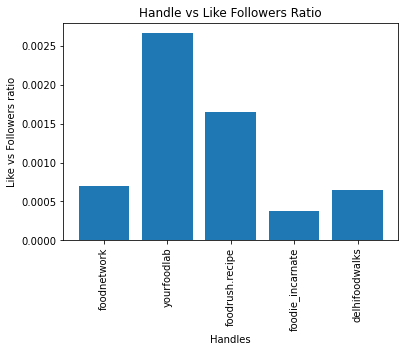

```python
import matplotlib.pyplot as plt
plt.bar(top_5,average_followers_likes)
plt.xticks(rotation=90)
plt.xlabel('Handles')
plt.ylabel('Like vs Followers ratio')
plt.title('Handle vs Like Followers Ratio')
plt.show()
```